# Project Python Foundations: FoodHub Data Analysis

### Context

The number of restaurants in New York is increasing day by day. Lots of students and busy professionals rely on those restaurants due to their hectic lifestyles. Online food delivery service is a great option for them. It provides them with good food from their favorite restaurants. A food aggregator company FoodHub offers access to multiple restaurants through a single smartphone app.

The app allows the restaurants to receive a direct online order from a customer. The app assigns a delivery person from the company to pick up the order after it is confirmed by the restaurant. The delivery person then uses the map to reach the restaurant and waits for the food package. Once the food package is handed over to the delivery person, he/she confirms the pick-up in the app and travels to the customer's location to deliver the food. The delivery person confirms the drop-off in the app after delivering the food package to the customer. The customer can rate the order in the app. The food aggregator earns money by collecting a fixed margin of the delivery order from the restaurants.

### Objective

The food aggregator company has stored the data of the different orders made by the registered customers in their online portal. They want to analyze the data to get a fair idea about the demand of different restaurants which will help them in enhancing their customer experience. Suppose you are hired as a Data Scientist in this company and the Data Science team has shared some of the key questions that need to be answered. Perform the data analysis to find answers to these questions that will help the company to improve the business.

### Data Description

The data contains the different data related to a food order. The detailed data dictionary is given below.

### Data Dictionary

- order_id: Unique ID of the order
- customer_id: ID of the customer who ordered the food
- restaurant_name: Name of the restaurant
- cuisine_type: Cuisine ordered by the customer
- cost_of_the_order: Cost of the order
- day_of_the_week: Indicates whether the order is placed on a weekday or weekend (The weekday is from Monday to Friday and the weekend is Saturday and Sunday)
- rating: Rating given by the customer out of 5
- food_preparation_time: Time (in minutes) taken by the restaurant to prepare the food. This is calculated by taking the difference between the timestamps of the restaurant's order confirmation and the delivery person's pick-up confirmation.
- delivery_time: Time (in minutes) taken by the delivery person to deliver the food package. This is calculated by taking the difference between the timestamps of the delivery person's pick-up confirmation and drop-off information

### Let us start by importing the required libraries

```python
# Installing the libraries with the specified version.
!pip install numpy==1.25.2 pandas==1.5.3 matplotlib==3.7.1 seaborn==0.13.1 -q --user
```

**Note**: *After running the above cell, kindly restart the notebook kernel and run all cells sequentially from the start again.*

```python
# import libraries for data manipulation
import numpy as np
import pandas as pd

# import libraries for data visualization
import matplotlib.pyplot as plt
import seaborn as sns
```

### Understanding the structure of the data

```python
# uncomment and run the following lines for Google Colab
from google.colab import drive
drive.mount('/content/drive')
```

```python
# Write your code here to read the data
df=pd.read_csv('/content/drive/MyDrive/Colab Notebooks/foodhub_order.csv')
```

```python
# Write your code here to view the first 5 rows
df.head()
```

|  | order_id | customer_id | restaurant_name | cuisine_type | cost_of_the_order | day_of_the_week | rating | food_preparation_time | delivery_time |
| --- | --- | --- | --- | --- | --- | --- | --- | --- | --- |
| 0 | 1477147 | 337525 | Hangawi | Korean | 30.75 | Weekend | Not given | 25 | 20 |
| 1 | 1477685 | 358141 | Blue Ribbon Sushi Izakaya | Japanese | 12.08 | Weekend | Not given | 25 | 23 |
| 2 | 1477070 | 66393 | Cafe Habana | Mexican | 12.23 | Weekday | 5 | 23 | 28 |
| 3 | 1477334 | 106968 | Blue Ribbon Fried Chicken | American | 29.20 | Weekend | 3 | 25 | 15 |
| 4 | 1478249 | 76942 | Dirty Bird to Go | American | 11.59 | Weekday | 4 | 25 | 24 |

**Observation**: Data frame df has 9 columns, Data in each row corresponds to the order placed by a customer

### **Question 1:** How many rows and columns are present in the data? [0.5 mark]

```python
# Write your code here
df.shape
```

```
(1898, 9)
```

### **Question 2:** What are the datatypes of the different columns in the dataset? (The info() function can be used) [0.5 mark]

```python
# Write your code here
df.info()
```

```
<class 'pandas.core.frame.DataFrame'>
RangeIndex: 1898 entries, 0 to 1897
Data columns (total 9 columns):
 #   Column                 Non-Null Count  Dtype
---  ------                 --------------  -----
 0   order_id               1898 non-null   int64
 1   customer_id            1898 non-null   int64
 2   restaurant_name        1898 non-null   object
 3   cuisine_type           1898 non-null   object
 4   cost_of_the_order      1898 non-null   float64
 5   day_of_the_week        1898 non-null   object
 6   rating                 1898 non-null   object
 7   food_preparation_time  1898 non-null   int64
 8   delivery_time          1898 non-null   int64
dtypes: float64(1), int64(4), object(4)
memory usage: 133.6+ KB
```

#### Observations:

- There are total 1898 non-null observations in the each of the column.
- The dataset contains 9 columns:- 4 are of Interger Type(order_id,customer_id,food_preparation_time,delivery_time),4 are of general object type(restaurant_name,cuisine_name,day_of_the_week,rating) and 1 is float Type(cost_of_the_order)
- Total memory usage is approximately 133.6 KB

### **Question 3:** Are there any missing values in the data? If yes, treat them using an appropriate method. [1 mark]

```python
# Write your code here
# checking missing values in data
df.isnull().sum()
```

|  | 0 |
| --- | --- |
| order_id | 0 |
| customer_id | 0 |
| restaurant_name | 0 |
| cuisine_type | 0 |
| cost_of_the_order | 0 |
| day_of_the_week | 0 |
| rating | 0 |
| food_preparation_time | 0 |
| delivery_time | 0 |

**dtype:** int64

#### Observations:

- There are no missing values in the Dataset

### **Question 4:** Check the statistical summary of the data. What is the minimum, average, and maximum time it takes for food to be prepared once an order is placed? [2 marks]

```python
# Write your code here
# get statistic summury of numerical data
df.describe()
```

|  | order_id | customer_id | cost_of_the_order | food_preparation_time | delivery_time |
| --- | --- | --- | --- | --- | --- |
| count | 1.898000e+03 | 1898.000000 | 1898.000000 | 1898.000000 | 1898.000000 |
| mean | 1.477496e+06 | 171168.478398 | 16.498851 | 27.371970 | 24.161749 |
| std | 5.480497e+02 | 113698.139743 | 7.483812 | 4.632481 | 4.972637 |
| min | 1.476547e+06 | 1311.000000 | 4.470000 | 20.000000 | 15.000000 |
| 25% | 1.477021e+06 | 77787.750000 | 12.080000 | 23.000000 | 20.000000 |
| 50% | 1.477496e+06 | 128600.000000 | 14.140000 | 27.000000 | 25.000000 |
| 75% | 1.477970e+06 | 270525.000000 | 22.297500 | 31.000000 | 28.000000 |
| max | 1.478444e+06 | 405334.000000 | 35.410000 | 35.000000 | 33.000000 |

#### Observations:

- order_id and customer_id are just identifiers of each other.
- The cost of order ranges from min 4.47 to max 35.41 dollars, with the average cost of order is 16.49 dollars and standard deviation is 7.48 dollars. The cost of 75% of orders are below 23 dollars.which indicates that customer prefers low cost food rather than expensive food.
- Food preparation time range is min 20 mins to max 35 mins, the average food prepartion time is around 27 mins with standard deviation 4.6 mins. 75% of reaturants takes less than 31 mins to prepare their food which doesn't make more difference.
- delivery time range is min 15 to max 33 minutes, with average of around 24 mins and standard deviation is 4.97 mins. It doesn't make much difference either.

### **Question 5:** How many orders are not rated? [1 mark]

```python
# Write the code here
# using value_counts()
df['rating'].value_counts()
```

| rating | count |
| --- | --- |
| Not given | 736 |
| 5 | 588 |
| 4 | 386 |
| 3 | 188 |

**dtype:** int64

#### Observations:

- There are 736 orders which has not rated

### Exploratory Data Analysis (EDA)

### **Question 6:** Explore all the variables and provide observations on their distributions. (Generally, histograms, boxplots, countplots, etc. are used for univariate exploration.) [9 marks]

**OrderID**

```python
# Cheque unique orderID
df['order_id'].nunique()
```

```
1898
```

### Observation:

- There are 1898 unique orders,and order_id is just a identifier for the orders.

**Customer ID**

```python
# check uniquue customer IDs
df['customer_id'].nunique()
```

```
1200
```

### Observation

- There are 1200 unique customers, here we can see the no of unique customers are less than the no of unique orders, which means some customer placed multiple orders.

**Restaurant Name**

```python
# check unique restaurant name
df['restaurant_name'].nunique()
```

```
178
```

#### Observation

- There are 178 unique restaurants are present in dataset.

```python
# no of orders served by restaurants
df['restaurant_name'].value_counts()
```

| restaurant_name | count |
| --- | --- |
| Shake Shack | 219 |
| The Meatball Shop | 132 |
| Blue Ribbon Sushi | 119 |
| Blue Ribbon Fried Chicken | 96 |
| Parm | 68 |
| ... | ... |
| Rye House | 1 |
| Hiroko's Place | 1 |
| Frank Restaurant | 1 |
| Sarabeth's West | 1 |
| 'wichcraft | 1 |

178 rows × 1 columns

**dtype:** int64

#### Observation

- The restaurant Shake Shack has received the maximum no. of orders which is 219

**Cuisine Type**

```python
# check how many different cuisines are in dataset
df['cuisine_type'].nunique()
```

```
14
```

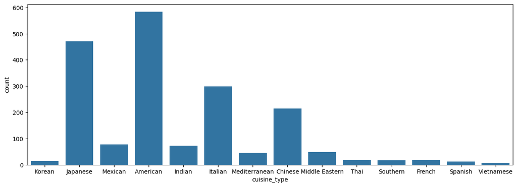

```python
# let's check countplot for cuisines
plt.figure(figsize=(15,5))
sns.countplot(data=df,x='cuisine_type');
```